# Estimating population size and reduction from removals

(with emphasis on wild deer and wild pigs)

Peter Caley (peter.caley@csiro.au) with Andrew Bengsen and Dave Forysth

2024-06-27

# Introduction

Central to using culling/removal rate to estimate abundance is the underlying relationship between the rate of culling (predation) and population density/size — the functional response. This is an example of an ``inverse problem’’ in inference, where we seek to estimate the initial abundance/density on the basis of the rate of removal.

Some key points to note.

- If the functional response relationship is well known, then only a single shooting session covering a representative sample of the area of interest would be required to obtain an estimate of initial population size/density. Note there are a bunch of qualifiers to this. For example, if the density is above the level at at which shooting saturation occurs, then only the lower bound for the estimate of density will be estimated with any precision.
- If the functional response relationship is not known, then it needs to be estimated, which requires that the proportion of the population removed during sessions is sufficient to generate a decline in the kill rate enabling calibration. If there is no detectable decline in the culling rate, then the estimated population under saturating forms of the functional response is infinite.
- Finally, there is likely to be prior information available on the likely density of animals within the area of interest, along with the dominant vegetation type and what effect this may have on shape of the functional response relationship. Where such information is available and can be expressed quantitatively, Bayesian statistical methods are typically the best way of incorporation.

Examples of the application of predator-prey theory to the shooting of feral pigs from a helicopter include Saunders and Bryant (1988), Hone (1990) and Choquenot *et al.* (1999). A more recent application to controlling wild deer (and a review of ungulates in general) is that of Bengsen *et al.* (2023). These studies use a range of functions to describe the relationship between the number of animals shot per unit shooting effort and abundance/density. They are reviewed here.

## Functional response types

### Ivlev

Bengsen *et al.* (2023) used a modified form of the Ivlev function to model the kill rate ($c$) achieved by a helicopter shooting team as a function of deer density ($x$). The function takes the form:

$$c = -b + a(1 - e^{-dx}).$$
Note that the parameters $a$ and $b$ aren’t interpretable exactly as stated by Bengsen *et al.* (2023). In particular, the density below which animals are effectively unable to be shot is not $b$, but rather the x-intercept (where the curve crosses the x axis) that is controlled by $b$ interacting with $d$. In a similar vein, the maximum rate of removal is $c_{max}=a-b$ (not to simply $a$ as stated). It is possible, however, to calculate that values for $a$ and $b$ that give the desired value for the density of animals unable to be removed ($x_{min}$). Substituting $a = c_{max} + b$ into the Ivlev function with $c$ set to zero enables the required value of $b$ to be estimated as:

$$b = c_{max}(e^{d x_{min}}-1).$$
That said, examining the Ivlev functional response models fitted to the aerial shooting data of deer in Bengsen *et al.* (2023) doesn’t indicate that a portion of the population is unable to be shot (see their Fig. 4). The requirement to have a functional response where a portion of the population is unable to be shot arose during aerial shooting of wild pigs where the habitat included areas of dense vegetation Choquenot *et al.* (1999). Modifying the Ivlev function to be non-zero is essentially changing it to a Type-III (i.e. sigmoidal) functional response.

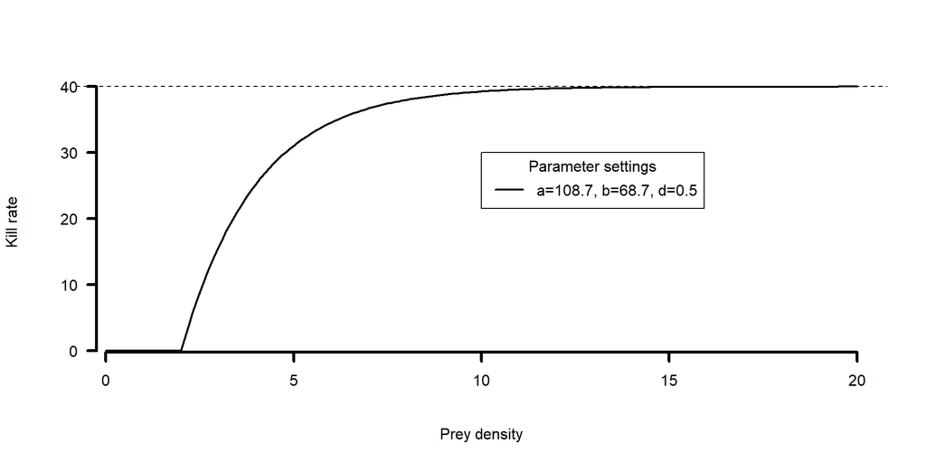

Example of Ivlev functional response (modified to only take positive values) with parameters chosen to achieve a maximum kill rate of 40 hr$^{-1}$ and a density of 2 below which culling becomes ineffective.

The Ivlev function is particularly suited to the analysis of numerical response (e.g. Caughley (1987)) where the rate of population increase ($r$) can take on negative values, and the parameters can be sensibly interpreted. For example, $b$ is the maximum rate of decrease in the absence of food, and $r=a-b$ is the maximum rate of increase when food isn’t limiting. It is, however, probably less well suited as a functional response, where the predation rate can’t be negative.

Choquenot *et al.* (1999) used what they termed a ``consonant’’ model used by Short (1987) to describe variation in the kill rate (kills h$^{-1}$) of a shooting team consisting of a pilot and single shooter as a function of pig density (pigs km$^{-2}$) as:

$$\text{kill rate} = a (1 - e^{-d(x-b)}).$$

Where:  
$x=$ density of target/prey species (here wild pigs),  
$a=$ the maximum offtake rate (realised at large $x$),  
$b=$ density of target animals below which detection and killing in impossible, and  
$d=$ parameter controlling the rate of encounter between the hunting process and the target animal [ToDo. Check by simulation]

The parameterisation of this model as some advantages over the Ivlev one in terms of interpretability — the maximum rate of shooting at saturation is specified directly by $a$ (rather than $a - b$), and the density at which animals cannot no longer be detected is exactly $b$ (c.f. being calculated numerically). This is an advantage when it comes to using prior knowledge within a Bayesian modelling framework, in that the specification of prior distributions is straightforward — not a consideration when the paper was being written.

Note that the units of the kill rate could also be expressed as kills per area per unit time.

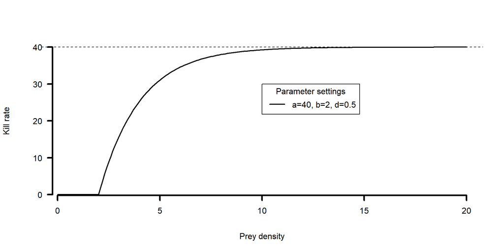

Example of functional response used by Choquenot *et al.* (1999).

The specification of a proportion of animals being unable to be preyed on is an approximation (e.g. where a proportion of animals learn to use and have access to refuges with zero visibility). It’s inclusion by Choquenot *et al.* (1999) presumably reflects the first-hand experience of the authors. For example, Saunders and Bryant (1988) document pigs that were known (from radio-collaring data) to be present though never sighted during a helicopter shooting exercise due to hiding in tall reeds. It assumes that removing animals becomes infinitely expensive (by shooting from a helicopter at least).

### Alternatives Type III functional responses

It is somewhat strange that Choquenot *et al.* (1999) didn’t choose one of the standard functional responses relating predation rate to prey density. For example, following Pech *et al.* (1992) a Type III response can be of the form:

$$c = \frac{\beta_0 x^2}{\beta_1^2 + x^2}$$

Here the kill rate saturates at $\beta_0$. A limitation of this 2-parameter form of a Type III response is that it is difficult to have a pronounced sigmoidal shape that captures a significant density of prey that are unavailable, without a pronounced flattening of the curve (i.e. the shooting rate is slow to reach saturation). This can be addressed by allowing the exponent of $x$ to be free ($k$). Increasing $k$ shortens the time to reaching shooting saturation. Combinations of high values of both $k$ and $\beta_1$ can produce more pronounced sigmoidal shapes, similar to the ‘generalised’ Type III functional response (see below).

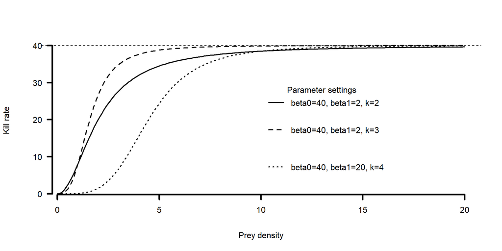

Example of Holling Type III functional response used by Pech *et al.* (1992).

A slightly more general, 3-parameter Type III functional response takes the form:

$$c = \frac{\beta_0 x^k}{1 + \beta_0 \beta_1 x^k}$$

Where the kill rate saturates at $1/\beta_1$, and the additional parameter $k$ determines how quickly (in terms of increasing density) shooting saturation is reached. Higher rates of $k$ enable a more pronounced sigmoidal shape. Note that once prey density increases beyond the minimum (effectively $c_{max}$) the slope should not exceed one. That is, the kill rate shouldn’t increase more quickly than the increase in prey density [Specifying statistical priors to achieve this may be a touch challenging …].

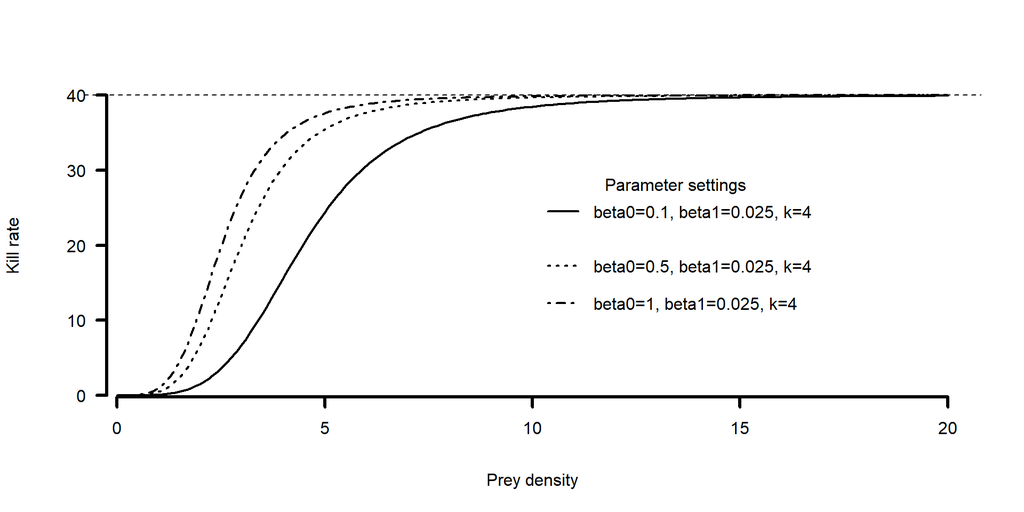

Example of generalised Type III functional response.

```r
if(PLOT.IT) {
  pars1 <- list(beta0=0.1, beta1=1/40, k=4, x.vals=seq(0, 20, 0.1))
  pars2 <- list(beta0=0.1, beta1=1/40, k=5, x.vals=seq(0, 20, 0.1))
  pars3 <- list(beta0=0.5, beta1=1/40, k=4, x.vals=seq(0, 20, 0.1))
  pars4 <- list(beta0=1.0, beta1=1/40, k=4, x.vals=seq(0, 20, 0.1))
  with(pars1, {
         plot(x.vals, TypeIIIGeneral(x.vals, beta0, beta1, k), type='l', lwd=2, xlim=c(0,max(x.vals)), xlab="Prey density", ylab="Kill rate", axes=F)
      axis(1, lwd=3, pos=-0.2)
      axis(2, lwd=3, pos=-0.25, las=2)
      abline(h=40, lty=2)
       #lines(x.vals, TypeIIIGeneral(x.vals, beta0=0.05, beta1=0.1, k=4), lty=2)
       legend(10, 30, paste0("beta0=", beta0, ", beta1=", beta1, ", k=", k), lty=c(1), lwd=2, title="Parameter settings", bty='n')
  })
  with(pars3, {
         lines(x.vals, TypeIIIGeneral(x.vals, beta0, beta1, k), type='l', lwd=2, lty=3, xlim=c(0,max(x.vals)), xlab="Prey density", ylab="Kill rate")
       legend(10, 20, paste0("beta0=", beta0, ", beta1=", beta1, ", k=", k), lty=c(3), lwd=2, bty='n')
  })
  with(pars4, {
         lines(x.vals, TypeIIIGeneral(x.vals, beta0, beta1, k), type='l', lwd=2, lty=4, xlim=c(0,max(x.vals)), xlab="Prey density", ylab="Kill rate")
       legend(10, 15, paste0("beta0=", beta0, ", beta1=", beta1, ", k=", k), lty=c(4), lwd=2, bty='n')
  })
}
```

## Choice of functional response

Do we need to species-dependent choices, or species x habitat-dependent choices, or can a 3-parameter Type III cover all?

# Fitting functional response models

Fitting functional response models requires that density is known (from a pre-control survey) or can be estimated jointly. Analyses to date (e.g. Choquenot *et al.* 1999) have tended to assume the pre-control population is measured without uncertainty. A better approach would be to include uncertainty in the estimate of the pre-control population density. This naturally sends us down the Bayesian path.

```r
# Fitting functional response.
```

# Simulation of shooting data from known populations

It will be useful for model testing and development to be able to simulate realistic removal data from a known population.

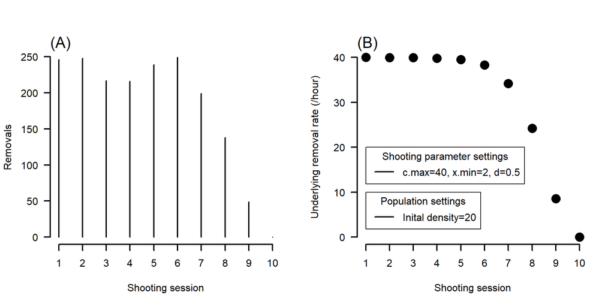

```r
# Ivlev example
out <- simShoot(n0=20, A=100, T=10, c.max=40, x.min=2, d=0.5, effort.mu=6, effort=NULL, searchFunc="Ivlev" )
# Plot it
with(out, {
  par(mfrow=c(1,2))
  plot(1:T, cull.no, type='h', lwd=2, ylab="Removals", xlab="Shooting session", axes=FALSE)
  axis(1, lwd=2, at=t)
  axis(2, lwd=2, las=2)
  mtext("(A)", side=3, adj=0, cex=1.5)
  plot(1:T, mu, pch=16, cex=2, lwd=2, ylab="Underlying removal rate (/hour)", xlab="Shooting session", axes=FALSE, ylim=c(0, max(mu, na.rm=TRUE)))
  axis(1, lwd=2, at=t)
  axis(2, lwd=2, las=2)
  mtext("(B)", side=3, adj=0, cex=1.5)
  legend(1, 20, paste0("c.max=", c.max, ", x.min=", x.min, ", d=", d), lty=(1), lwd=2, title="Shooting parameter settings")
  legend(1, 10, paste0("Inital density=", n0), lty=(1), lwd=2, title="Population settings")
  })
```

1. Simulated removals, and (B) Simulated culling rate assuming an Ivlev functional response.

Generate some simulated data.

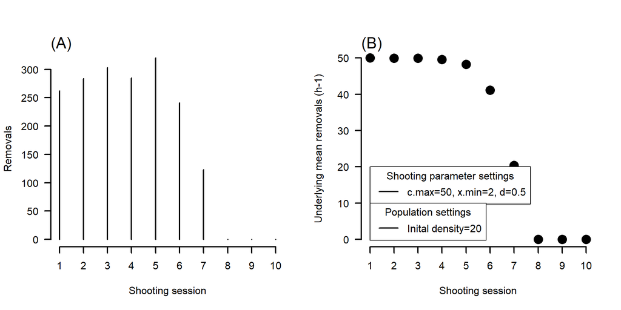

1. Simulated removals, and (B) Simulated culling rate assuming a Choquenot-like response.

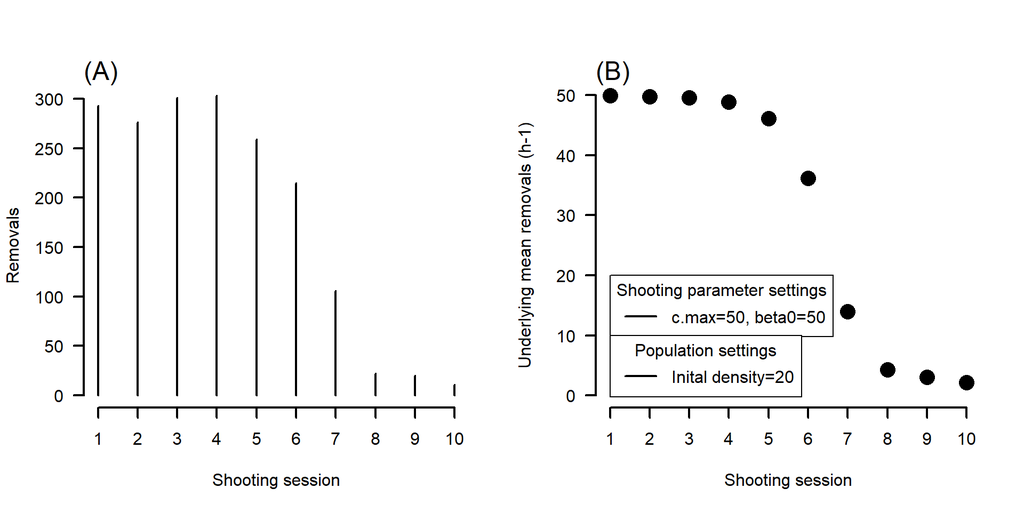

1. Simulated removals, and (B) Simulated culling rate assuming a Type III functional functional response.

# Removal estimators

Contexts for the use of removal estimators include:

- single estimate of culls per unit area (i.e. no area re-searched in discrete session)
- …

## Approach of Ramsey *et al.* (2023)

Ramsey *et al.* (2023) don’t choose a particular functional response when developing a removal estimator for deer populations subject to repeated periods of shooting, where each period comprises several shooting sessions. Key differences to the previous papers discussed include the absence of density dependence in the probability of being shot (i.e. no saturation in the culling rate arising from a fixed handling time per animal).

## Approaches using parametric forms for the functional response

First up a model using a Type III numerical response.

```r
# Model for Type III estimation
cat("
model {
  # Priors
  n0 ~ dnorm(n0.hat, pow(se.n0.hat,-2))T(0,)
  beta0 ~ dgamma(beta0_shape, beta0_rate)
  beta1 ~ dgamma(beta1_shape, beta1_rate)
  k ~ dgamma(k_shape, k_rate)

  N0 <- n0*A
  N[1] <- round(N0)
  # Density
  n[1] <- n0
  # Kill rate (Type III)
  # Functional Response model for cull rate
  mu[1] <- beta0*n[1]^k/(beta1^2 + n[1]^k)
  # Culls likelihood
  x[1] ~ dpois(mu[1]*cull.eff[1])
  # Over shooting sessions
  for (i in 2:max(T)) {
    # Remove culls at end of previous period
    N[i] <- N[i-1] - x[i-1]
    # Calculate density
    n[i] <- N[i]/A
    # Functional Response model for cull rate
    mu[i] <- beta0*n[i]^k/(beta1^2 + n[i]^k)
    # Culls likelihood
    x[i] ~ dpois(mu[i]*cull.eff[i])
  }

  # Predictive distribution
  for(j in 1:length(n_pred)) {
    mu_pred[j] <- beta0*n_pred[j]^k/(beta1^2 + n_pred[j]^k)
  }
}", file="estTypeIII.jags")
```

### Recovering parameters from known simulation …

First up we examine whether we can recover the latent (unobserved) states of the populations underlying simulated shooting datasets.

Check out posteriors.

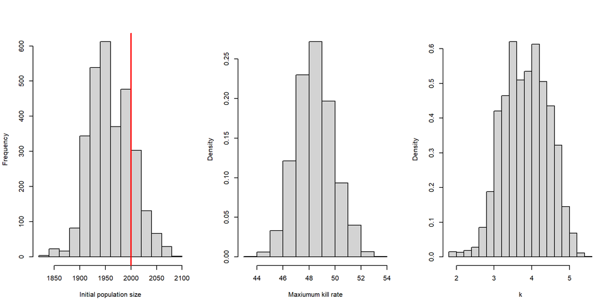

Check stuff …

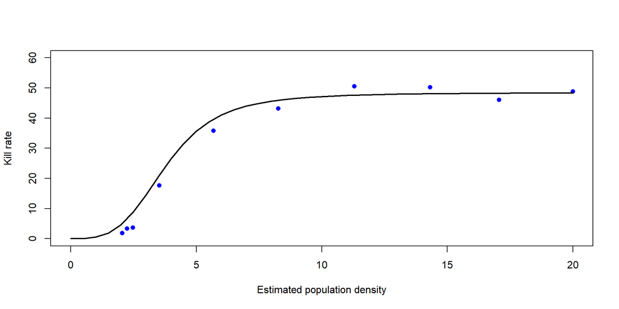

```r
# Calculate mean kill rates
mu.col.names <- paste0("mu[",simTypeIII$t,"]")
mu.means <- apply(post[ , mu.col.names],2,mean)
mu.pred.col.names <- paste0("mu_pred[", 1:length(mod.data.sim$n_pred), "]")
mu.pred.means <- apply(post[, mu.pred.col.names], 2, mean)
n.col.names <- paste0("n[", simTypeIII$t, "]")
n.means <-  apply(post[,n.col.names], 2, mean)

with(simTypeIII,{
  plot(x, cull.no/cull.eff, pch=16, col='blue', xlim=c(0,n0), ylim=c(0,max(1.2*simTypeIII$beta0)),
       xlab="Estimated population density", ylab="Kill rate")
})
lines(mod.data.sim$n_pred, mu.pred.means, lwd=2)
```

# Fitting different models to existing datasets

## Feral/wild pigs

Hone (1990) and Saunders and Bryant (1988) reported on aerial shooting operation operations of feral pigs on the Mary River floodplain (Northern Territory) and Macquarie Marshes (western NSW), respectively.

Aerial shooting data of feral pigs from Mary River Flooplain, Northern Territory. Reproduced from Hone (1990).

| Day | Effort | Kills | KillRate | KillsKm2 |
| --- | --- | --- | --- | --- |
| 1 | 4.425 | 300 | 67.8 | 1.017 |
| 2 | 6.490 | 139 | 21.4 | 0.471 |
| 3 | 4.720 | 185 | 39.2 | 0.627 |
| 4 | 1.770 | 62 | 35.0 | 0.210 |
| 5 | 4.720 | 263 | 55.8 | 0.892 |
| 6 | 5.310 | 167 | 31.4 | 0.566 |
| 7 | 2.065 | 122 | 59.1 | 0.414 |
| 8 | 5.605 | 153 | 27.3 | 0.519 |
| 9 | 4.720 | 43 | 9.1 | 0.146 |

Aerial shooting data of feral pigs from Macquarie Marshes, Western NSW. Reproduced from Saunders and Bryant (1988).

| Day | Effort | Kills | KillRate | KillsKm2 |
| --- | --- | --- | --- | --- |
| 1 | 4.25 | 208 | 48.94 | 1.73 |
| 2 | 6.75 | 417 | 61.78 | 3.48 |
| 3 | 7.00 | 316 | 45.14 | 2.63 |
| 4 | 5.50 | 74 | 13.45 | 0.62 |

A notable feature of the Mary River operation data is the modest decline in the kill rate (see Figure below). This may be a result of the shooters pseudo-systematic search pattern, whereby “shooting began on the perimeter of the area and continued towards the centre.” Hence some of the kill rates for later shooting sessions (e.g. Day 7) could arise from areas being shot for the first time. Other considerations for model specification include most of the open floodplain being covered with 1–2 metres of water. If the approx. one third of the study areas that was floodplain was subtracted from the total (295 km$^2$) this would change the estimates.

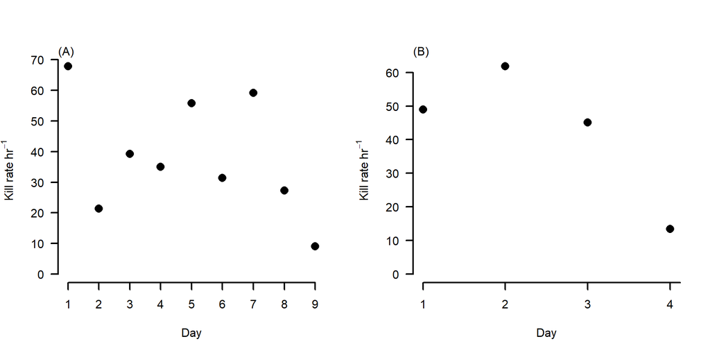

Data from aerial shooting operation reported by (A) Hone (1990) and (B) Saunders and Bryant (1988).

### Fitting Macquarie Marshes feral pig shoot data of Saunders and Bryant (1988).

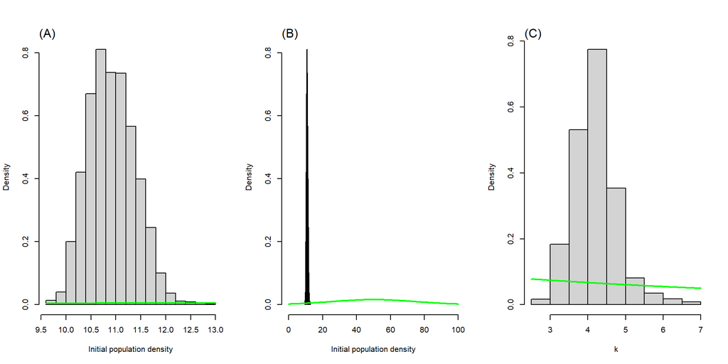

Posterior distributions (histograms) with priors (green lines) for (A) Initial population density, (B) Initial population density on wider scale to better illustrate prior, and (C) Parameter $k$.

```r
par(mfrow=c(1,3))
#hist(post[,'N[1]'], main="Initial population size", probability=TRUE)
hist(post[,'n[1]'], main="", probability=TRUE, xlab="Initial population density")
curve(dnorm(x, mean=50, sd=0.5*50), add=TRUE, col='green', lwd=2, )
mtext("(A)", 3, adj=0)
hist(post[,'n[1]'], main="", probability=TRUE, xlab="Initial population density", xlim=c(0,100))
# add prior
curve(dnorm(x, mean=50, sd=0.5*50), add=TRUE, col='green', lwd=2, )
mtext("(B)", 3, adj=0)
hist(post[,'k'], main="", probability=TRUE, xlab="k")
curve(dgamma(x, mod.data.MM1985$k_shape, mod.data.MM1985$k_rate), add=TRUE, col='green', lwd=2)
mtext("(C)", 3, adj=0)
```

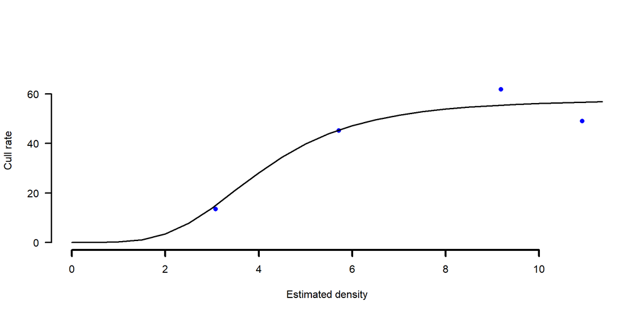

Kill rates as a function of estimated density for feral pigs on the Maquaries Marshes, western NSW. Source: Saunders and Bryant (1988)

```r
# Calculate mean kill rates
mu.col.names <- paste0("mu[", MM1985$Day, "]")
mu.means <-  apply(post[, mu.col.names], 2, mean)
mu.pred.col.names <- paste0("mu_pred[", 1:length(mod.data.MM1985$n_pred), "]")
mu.pred.means <- apply(post[, mu.pred.col.names], 2, mean)
n_hat.col.names <- paste0("n[", MM1985$Day, "]")
n_hat.means <-  apply(post[,n_hat.col.names], 2, mean)

with(mod.data.MM1985, {
     plot(n_hat.means, cull.rate, pch=16, col='blue', ylim=c(0, 1.2*max(cull.rate)), axes=FALSE, xlim=c(0, max(n_hat.means)),
          xlab="Estimated density", ylab="Cull rate")
  axis(1, lwd=3)
  axis(2, lwd=2, las=2)
})
lines(mod.data.MM1985$n_pred, mu.pred.means, pch=16, ylim=c(0,300), lwd=2,
      xlab="Estimated density", ylab="Kill rate")
```

### Mary River floodplain shoot from Hone (1990)

This shoot was undertaken in the wet season, with much of the floodplain covered in deep water. Shooting was undertaken from a Bell 47 helicopter.

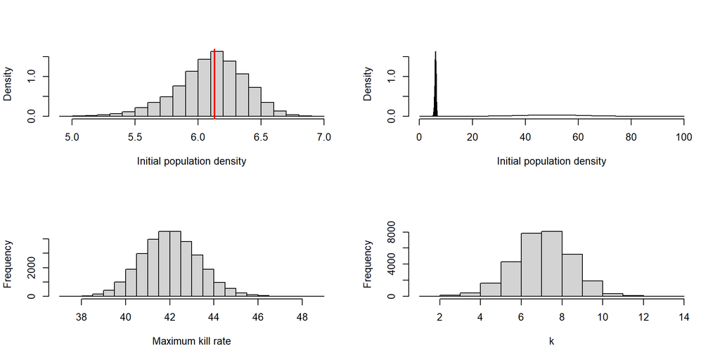

Posterior estimates for fitting model to shooting data of feral pigs from the Mary River Floodplain, Northern Territory.

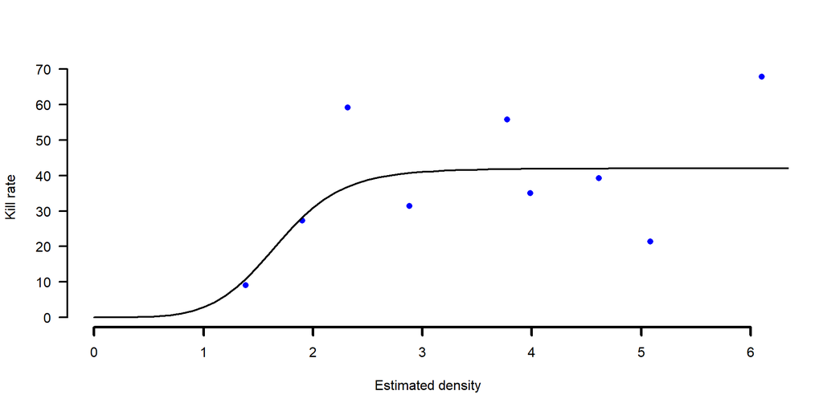

Kill rates as a function of estimated density for feral pigs on the Mary River Floodplain, Northern Territory. Source: Hone (1990)

### Combining multiple datasets …

```r
mod.data.comb <- list(
                T=c(nrow(MM1985), nrow(MR1986)),
                n0.hat=c(50, 50),   # from Giles (1980)
                se.n0.hat=c(0.5*50, 0.5*50), # Placeholder ... pretty flat
                beta0_shape=5,  beta0_rate=1/10, # mean 50
                beta1_shape=1, beta1_rate=1/10,   # mean 20
                k_shape=1, k_rate=1/10,
                cull.eff=list(MM1985$Effort, MR1986$Effort),
                cull.rate=MR1986$KillRate,
                cull.no=MR1986$Kills,
                x_pred=seq(0,10,0.1),
                A=295
                )
```

```r
# Model for Type III estimation with multiple data sets
cat("
model {
  # Priors
  for (j in 1:J){
    n0[j] ~ dnorm(n0.hat[j], pow(se.n0.hat[j],-2))T(0,)
  }
  beta0 ~ dgamma(beta0_shape, beta0_rate)
  beta1 ~ dgamma(beta1_shape, beta1_rate)
  k ~ dgamma(k_shape, k_rate)
  # Across sites
  for (j in 1:J) {
    N0[j] <- n0[j]*A[j]
    N[1,j] <- round(N0[j])
    # Density
    n[1,j] <- n0[j]
    # Functional Response model for cull rate (Type III)
    mu[1,j] <- beta0*n[1,j]^k/(beta1^2 + n[1,j]^k)
    # Culls likelihood
    cull.no[1,j] ~ dpois(mu[1,j]*cull.eff[1,j])
    # Over shooting sessions
    for (i in 2:T[j]) {
      # Remove culls at end of previous period
      N[i,j] <- N[i-1,j] - x[i-1,j]
      # Calculate density
      n[i,j] <- N[i,j]/A[j]
      # Functional Response model for cull rate
      mu[i,j] <- beta0*n[i,j]^k/(beta1^2 + n[i,j]^k)
      # Culls likelihood
      x[i,j] ~ dpois(mu[i,j]*cull.eff[i,j])
    }
  }
  # Predictive distribution for cull rate
  for(m in 1:length(n_pred)) {
    mu_pred[m] <- beta0*n_pred[m]^k/(beta1^2 + n_pred[m]^k)
  }
}", file="estTypeIIIcomb.jags")
```

```r
# Add missing data to Macquarie Marshes shoot
extra <- as.data.frame(cbind(5:9, matrix(NA, nrow=5, ncol=4)))
names(extra) <- names(MM1985)
MM1985PadNA <- rbind(MM1985, extra)

data.comb <- list(
                J=2, # Number of sites
                T=c(max(MM1985$Day), max(MR1986$Day)), # number of shooting sessions
                n0.hat=c(50, 6.1),   # from Giles (1980)
                #se.n0.hat=c(0.5*50, 0.5), # Placeholder ... pretty flat
                se.n0.hat=c(0.5*50, 5*6.1), # Placeholder ... pretty flat
                beta0_shape=5,  beta0_rate=1/10, # mean 50
                beta1_shape=1, beta1_rate=1/10,   # mean 20
                k_shape=1, k_rate=1/10,
                cull.eff=cbind(MM1985PadNA$Effort, MR1986$Effort),
                cull.rate=cbind(MM1985PadNA$KillRate, MR1986$KillRate),
                x=cbind(MM1985PadNA$Kills, MR1986$Kills),
                n_pred=seq(0,10,0.1),
                A=c(120,295)
                )

# Initialize model
simShoot.comb <- jags.model(
  file="estTypeIIIComb.jags",
  dat=data.comb,
  n.chains=3,
  n.adapt=1000
)
# Burn in
update(simShoot.comb, 1E3)

# Parameters of interest
params <- c("n0", "N0","N", "n", "beta0", "beta1", "mu", "mu_pred", "k")

# Get samples
simShoot.comb.coda <- coda.samples(simShoot.comb, params, 10E3)

post.comb <- as.matrix(simShoot.comb.coda)

#head(post.comb)
```

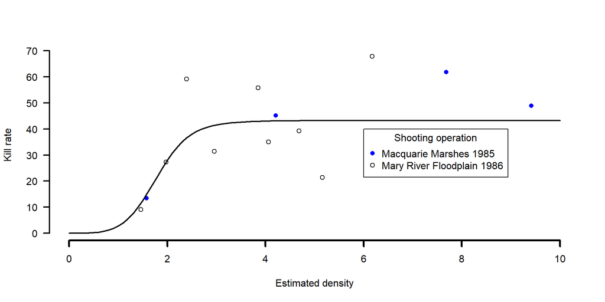

Kill rates of feral pigs during aerial shooting operations on the Mary River floodplain and Macquarie Marshes. Model fitted jointly to datasets with same parameterisation.

There is clearly something interesting going on here.

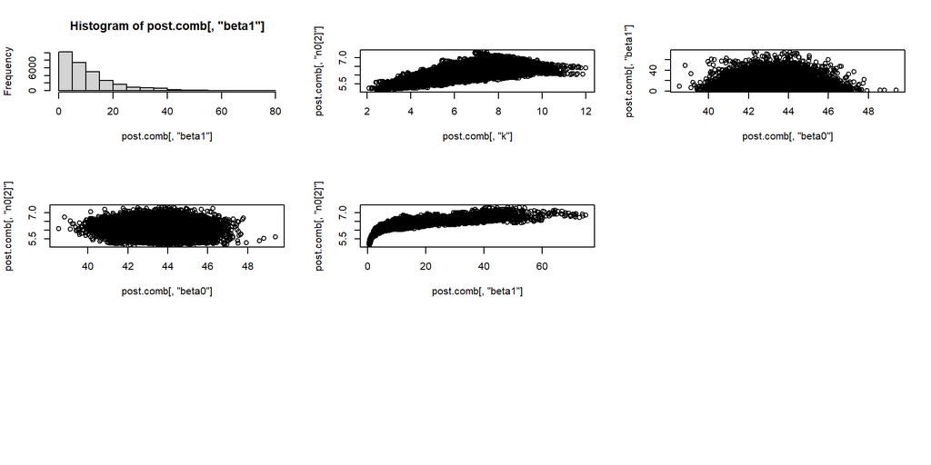

```r
par(mfrow=c(3,3))
hist(post.comb[,"beta1"])
plot(post.comb[,"k"], post.comb[,"n0[2]"])
plot(post.comb[,"beta0"], post.comb[,"beta1"])
plot(post.comb[,"beta0"], post.comb[,"n0[2]"])
plot(post.comb[,"beta1"], post.comb[,"n0[2]"])
```

## Wild deer

# References

Bengsen AJ, Forsyth DM, Pople A, Brennan M, Amos M, Leeson M, Cox TE, Gray B, Orgill O, Hampton JO, Crittle T, Haebich K (2023). Effectiveness and costs of helicopter-based shooting of deer. *Wildlife Research* **50**, 617–631. doi:10.1071/WR21156

Caughley G (1987). Ecological relationships. In ‘Kangaroos, their ecology and management in the sheep rangelands of australia’. (Eds G Caughley, N Shepherd, J Short.) Cambridge studies in applied ecology and resource management. pp. 159–187. (Cambridge University Press: Cambridge) doi:10.2307/5542

Choquenot D, Hone J, Saunders G (1999). Using aspects of predator-prey theory to evaluate helicopter shooting for feral pig control. *Wildlife Research* **26**, 251–261. doi:10.1071/WR98006

Hone J (1990). Predator-prey theory and feral pig control, with emphasis on evaluation of shooting from a helicopter. *Australian Wildlife Research* **17**, 123–130. doi:10.1071/WR9900123

Pech RP, Sinclair ARE, Newsome AE, Catling PC (1992). Limits to predator regulation of rabbits in australia: Evidence from predator-removal experiments. *Oecologia* **89**, 102–112. doi:10.1007/BF00319021

Ramsey DSL, McMaster D, Thomas E (2023). The application of catch–effort models to estimate the efficacy of aerial shooting operations on sambar deer (*cervus unicolor*). *Wildlife Research* **50**, 688–700. doi:10.1071/WR22123

Saunders G, Bryant H (1988). The evaluation of a feral pig eradication program during a simulated exotic disease outbreak. *Australian Wildlife Research* **15**, 73–81. doi:10.1071/WR9880073

Short J (1987). Ecological relationships. In ‘Kangaroos, their ecology and management in the sheep rangelands of australia’. (Eds G Caughley, N Shepherd, J Short.) Cambridge studies in applied ecology and resource management. pp. 84–99. (Cambridge University Press: Cambridge)